# 6 Peak Ultra Bead Tracking — Aurora EVO (5L)

Spectral QC: instrument-performance tracking from URCP-38-2K beads

Published

November 13, 2026

Secondary QC for the Cytek Aurora EVO from SPHERO **URCP-38-2K** Ultra Rainbow beads. The set resolves into **6 populations** — blank particles (peak 1) plus 5 fluorescent rainbow levels (peaks 2–6). **Note on the Aurora:** daily QC adjusts each APD’s *gain* to pin bead MFI to a target, so raw MFI is held ~constant by design — the informative signals are the ones gain can’t compensate: **sensitivity (2+2SD limit of resolution, Q & B)**, **%CV**, and **linearity**. Heavy FCS processing is done once by `scripts/Process6PeakUltra.R`; this page reads the `peak_metrics.csv` archive (+ the daily-QC gain) so it stays light.

# Detail

## Peak clustering

**NotePeak clustering — cluster images and cluster sizes (click to expand)**

The 6 URCP-38-2K populations are assigned **once per run** by model-based clustering (flowClust, K = 6) on the asinh-transformed anchor detectors, then read out in every detector. This is far more robust than per-detector peak finding: weak channels can’t resolve dim peaks alone, but the strong anchor detectors can, and a bead’s population label is fixed across all detectors. Labels are ordered 1–6 by ascending brightness: peak 1 = blank particles, peaks 2–6 = fluorescent rainbow levels. Clustering runs in `Process6PeakUltra.R`; this page reads the persisted result.

### 2D cluster assignment (V8-A × B9-A)

The per-run diagnostic: each run’s gated beads shown on two detectors that both resolve all 6 peaks. A clean assignment shows **6 tight, ordered, single-coloured blobs** along the diagonal — blank (peak 1) at the dim end, brightest (peak 6) at the top — with no interleaving.

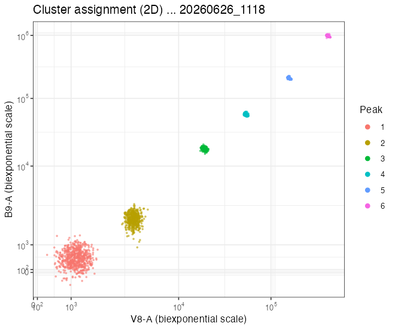

Run 20260626_1118

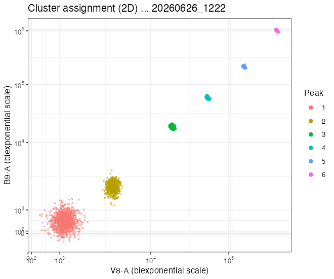

Run 20260626_1222

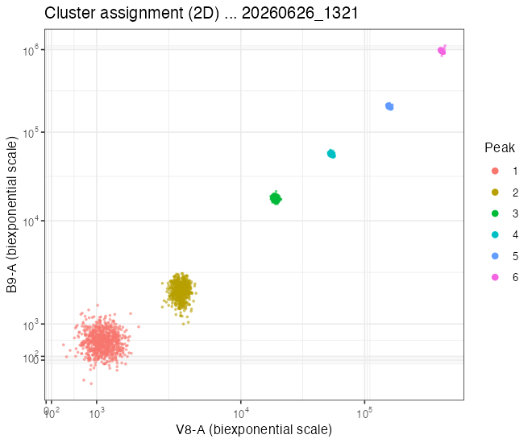

Run 20260626_1321

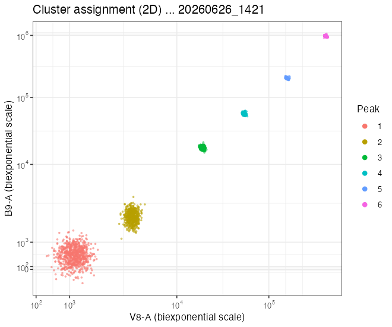

Run 20260626_1421

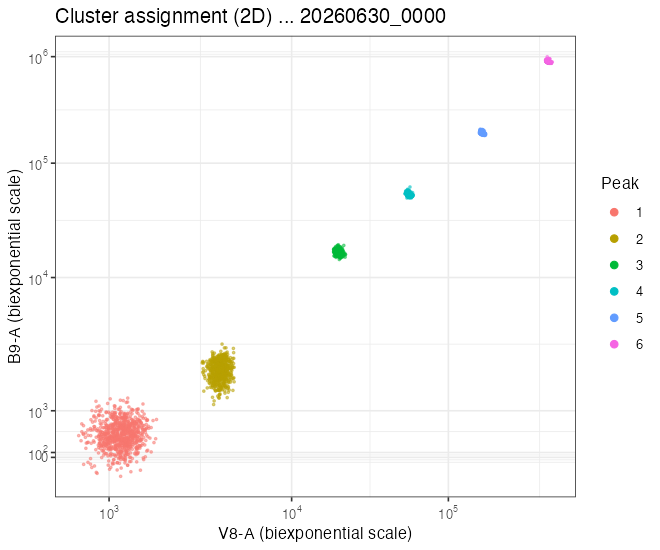

Run 20260630_0000

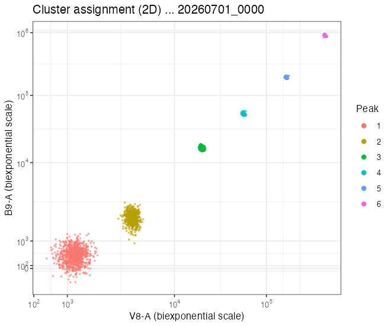

Run 20260701_0000

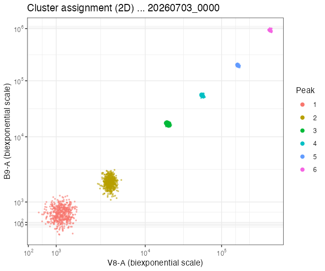

Run 20260703_0000

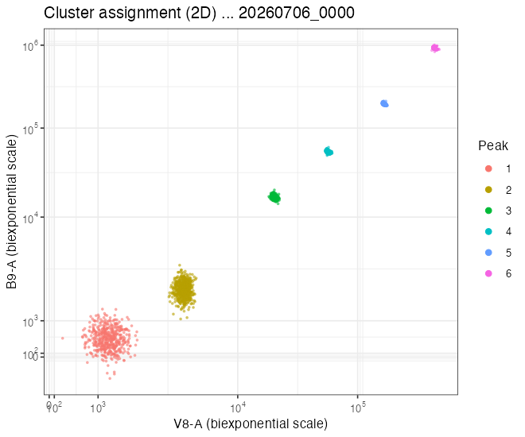

Run 20260706_0000

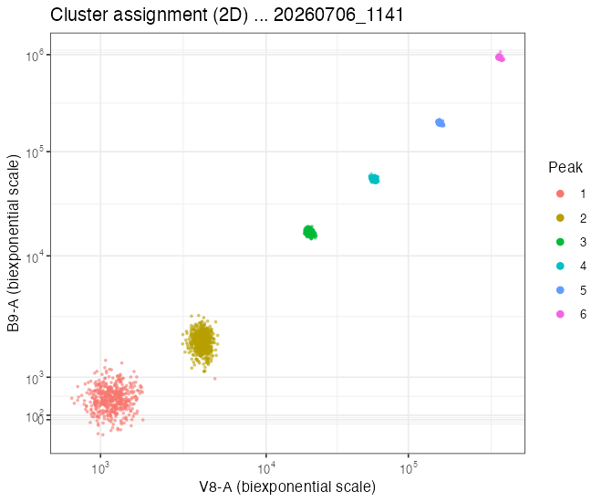

Run 20260706_1141

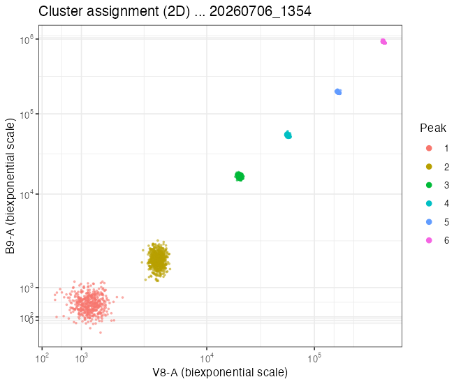

Run 20260706_1354

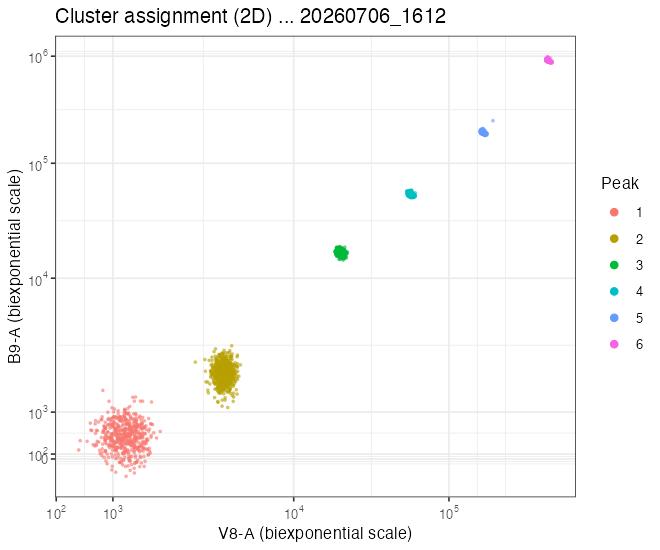

Run 20260706_1612

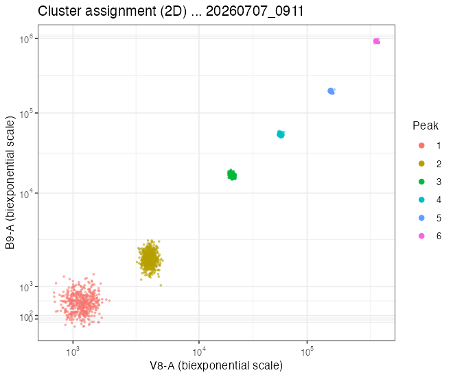

Run 20260707_0911

[15 more figures not shown]

```r
clus_imgs <- sort(list.files("images/6peak_ultra_evo", pattern = "^cluster2d_.*[.]png$", full.names = TRUE))
if (length(clus_imgs) == 0) cat("_No saved cluster images yet — run `scripts/Process6PeakUltra.R`._\n\n") else {
  cat("::: {layout-ncol=3}\n")
  for (f in clus_imgs) cat(sprintf("![Run %s](../%s)\n\n", sub("^cluster2d_(.*)[.]png$","\\1",basename(f)), f))
  cat(":::\n")
}
```

### Cluster-size sanity

URCP-38-2K mixes the 6 populations in roughly equal proportions (blank particles may be slightly more abundant). Cluster sizes should be broadly even — a quick numeric check that no population was split or merged by the clustering step.

```r
csz <- pm |> group_by(run_label, peak) |>
  summarise(events = mean(n, na.rm = TRUE), .groups = "drop") |>
  mutate(peak = factor(peak, levels = 1:n_peaks))
gp(ggplot(csz, aes(factor(peak), events, fill = run_label,
                   text = sprintf("peak %s | %s<br>mean events %.0f", peak, run_label, events))) +
     geom_col(position = position_dodge()) +
     labs(title = "Cluster size per peak (events per run; peak 1 = blank)",
          x = "Peak", y = "Events", fill = NULL) +
     theme_bw(base_size = 10), 300)
```

[interactive chart not shown]

## Tracking over time

Peak-6 median intensity and %rCV per laser across runs. A stable row means stable performance; a step or drift flags a laser problem. In-range peaks only.

### Per-laser overview

Two 5-laser × run heatmaps of peak-6 deviation from each detector’s baseline (first run), averaged across the laser. **Top:** median intensity shift (blue = dimmer, red = brighter). **Bottom:** %rCV shift (blue = tighter, red = broader). A whole-row shift points to a laser-level issue; an isolated tile flags a single detector.

```r
p6_base <- pm |> filter(peak == n_peaks, in_range) |> group_by(detector) |>
  slice_min(run_label, n = 1, with_ties = FALSE) |>
  transmute(detector, base_median = median) |> ungroup()
laser_delta <- pm |> filter(peak == n_peaks, in_range) |>
  left_join(p6_base, by = "detector") |>
  mutate(delta_pct = (median - base_median) / base_median * 100,
         laser = factor(laser_of(detector), levels = laser_levels)) |>
  group_by(laser, run_label) |> summarise(delta_pct = mean(delta_pct, na.rm = TRUE), .groups = "drop")
lim <- max(abs(laser_delta$delta_pct), na.rm = TRUE); if (!is.finite(lim) || lim == 0) lim <- 1
gp(ggplot(laser_delta, aes(run_label, laser, fill = delta_pct,
        text = sprintf("%s laser | %s<br>%+.1f%% vs baseline", laser, run_label, delta_pct))) +
     geom_tile(colour = "white") +
     scale_y_discrete(limits = rev(laser_levels)) +
     scale_fill_gradient2(low = "#2166ac", mid = "white", high = "#b2182b", midpoint = 0,
                          limits = c(-lim, lim), name = "Peak 6\nΔ median\nvs t0") +
     labs(title = "Per-laser peak-6 median deviation from baseline", x = NULL, y = "Laser") +
     theme_bw(base_size = 11) +
     theme(axis.text = element_text(size = 10)), 420)
```

[interactive chart not shown]

```r
p6_base_cv <- pm |> filter(peak == n_peaks, in_range) |> group_by(detector) |>
  slice_min(run_label, n = 1, with_ties = FALSE) |>
  transmute(detector, base_rcv = rcv) |> ungroup()
laser_delta_cv <- pm |> filter(peak == n_peaks, in_range) |>
  left_join(p6_base_cv, by = "detector") |>
  mutate(delta_pct = (rcv - base_rcv) / base_rcv * 100,
         laser = factor(laser_of(detector), levels = laser_levels)) |>
  group_by(laser, run_label) |> summarise(delta_pct = mean(delta_pct, na.rm = TRUE), .groups = "drop")
lim_cv <- max(abs(laser_delta_cv$delta_pct), na.rm = TRUE); if (!is.finite(lim_cv) || lim_cv == 0) lim_cv <- 1
gp(ggplot(laser_delta_cv, aes(run_label, laser, fill = delta_pct,
        text = sprintf("%s laser | %s<br>%+.1f%% vs baseline rCV", laser, run_label, delta_pct))) +
     geom_tile(colour = "white") +
     scale_y_discrete(limits = rev(laser_levels)) +
     scale_fill_gradient2(low = "#2166ac", mid = "white", high = "#b2182b", midpoint = 0,
                          limits = c(-lim_cv, lim_cv), name = "Peak 6\nΔ %rCV\nvs t0") +
     labs(title = "Per-laser peak-6 %rCV deviation from baseline", x = NULL, y = "Laser") +
     theme_bw(base_size = 11) +
     theme(axis.text = element_text(size = 10)), 420)
```

[interactive chart not shown]

## %CV & noise floor

Peak 6 (brightest) uses **robust %CV** — it has a well-defined mean (~1–2% when healthy). The blank (peak 1) uses its **absolute robust spread** (IQR/1.349), not %CV: the blank sits near zero, so %CV explodes when the mean dips toward zero even though the actual spread is unchanged. A rising blank spread is a genuine noise-floor increase.

```r
gp(heat(cvtop, "cvt", "Peak-6 %CV", "brightest population (mean well-defined)"))
```

[interactive chart not shown]

```r
gp(heat(cvp1, "sd1", "Peak-1 noise floor", "absolute robust spread (IQR/1.349), not %%CV"))
gp(heat_fc(cvp1, "sd1", "Noise floor — fold-change", "lower is better; red = noisier than its best", higher_better = FALSE))
```

[interactive chart not shown]

```r
cl_lat <- cvtop |> group_by(laser = factor(laser_of(detector), levels = laser_levels), run_label) |>
  summarise(cvt = mean(cvt, na.rm = TRUE), .groups = "drop")
gp(ggplot(cl_lat, aes(run_label, cvt, colour = laser, group = laser)) +
     geom_line() + geom_point() +
     labs(title = "Mean peak-6 %%CV per laser (± control context as runs accumulate)",
          x = NULL, y = "Peak-6 %%CV") + theme_bw(base_size = 10) +
     theme(axis.text.x = element_text(angle = 30, hjust = 1)), 320)
```

[interactive chart not shown]

## Per-run diagnostics

**NotePer-run diagnostics — bead gate images (click to expand)**

The bead gate saved by `Process6PeakUltra.R` per run — it should land on the dense scatter cluster. (The 2D cluster-assignment diagnostic is in the **Peak clustering** tab.)

### Bead gate (FSC-A × SSC-A)

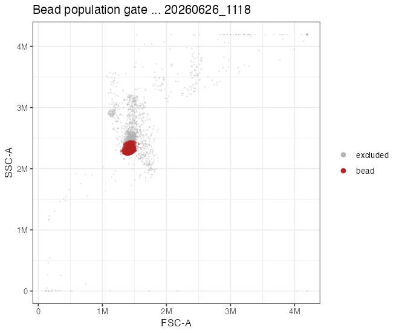

Run 20260626_1118

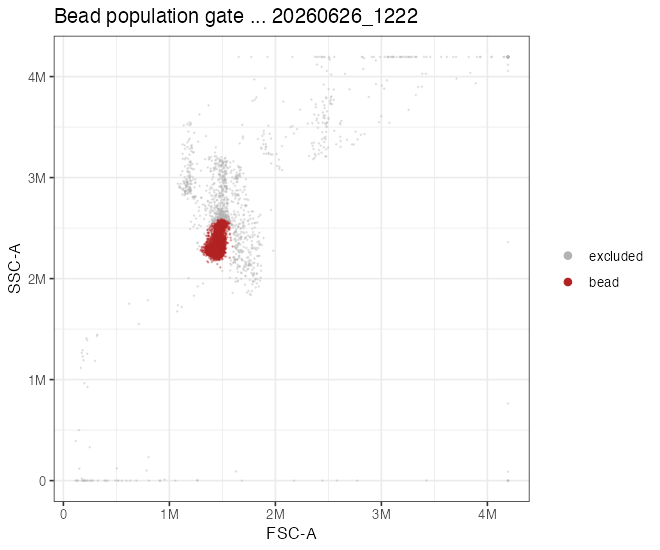

Run 20260626_1222

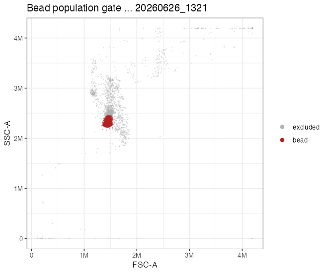

Run 20260626_1321

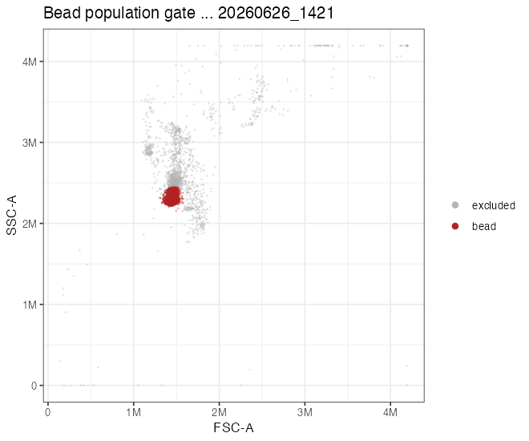

Run 20260626_1421

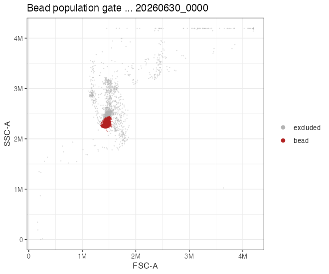

Run 20260630_0000

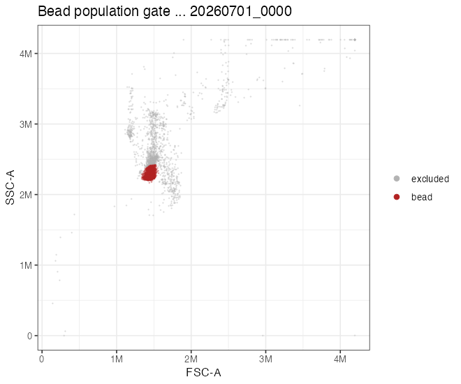

Run 20260701_0000

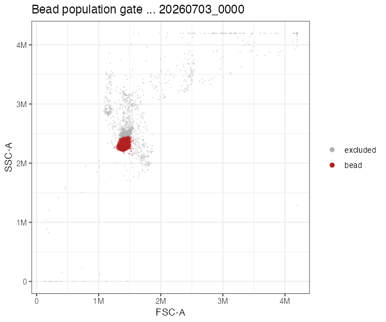

Run 20260703_0000

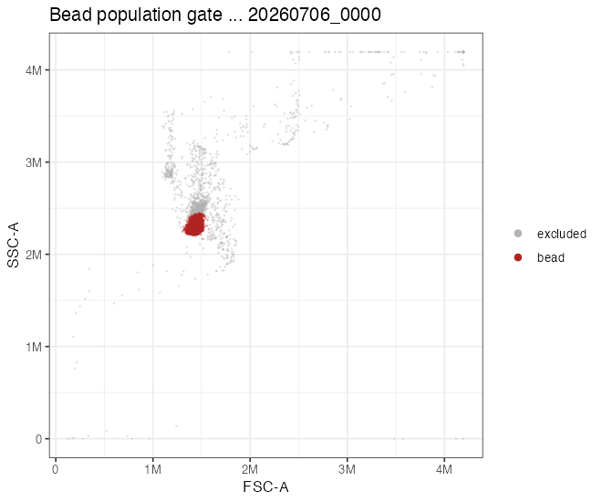

Run 20260706_0000

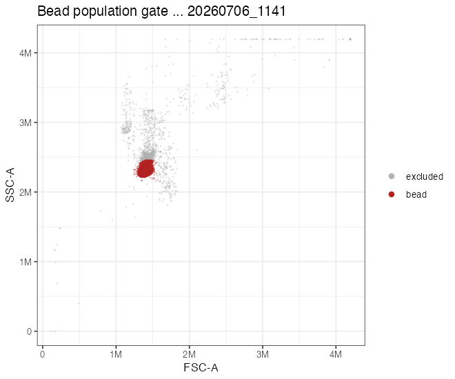

Run 20260706_1141

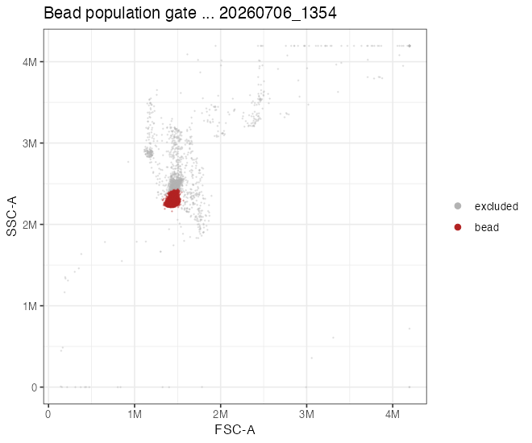

Run 20260706_1354

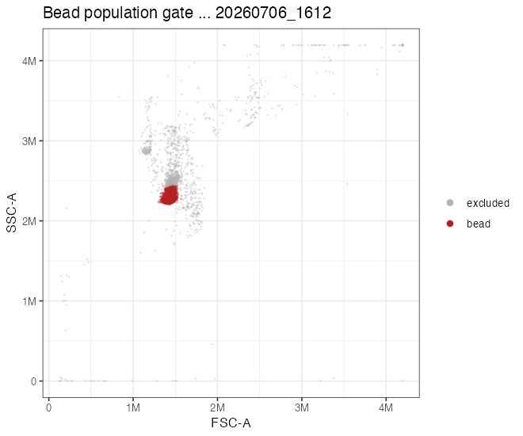

Run 20260706_1612

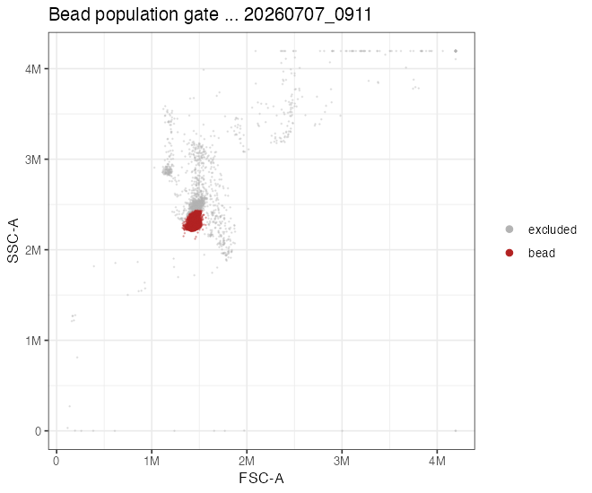

Run 20260707_0911

[15 more figures not shown]

```r
gate_imgs <- sort(list.files("images/6peak_ultra_evo", pattern = "^gate_.*[.]png$", full.names = TRUE))
if (length(gate_imgs) == 0) cat("_No saved gate images yet — run `scripts/Process6PeakUltra.R`._\n\n") else {
  cat("::: {layout-ncol=3}\n")
  for (f in gate_imgs) cat(sprintf("![Run %s](../%s)\n\n", sub("^gate_(.*)[.]png$","\\1",basename(f)), f))
  cat(":::\n")
}
```

## Sensitivity (2+2SD, Q & B)

**New method (2026-11-11).** Sensitivity now uses the Parks 2017 weighted quadratic fit and the Parks 2018 **2+2SD limit of resolution**, adopted from the cross-instrument Sensitivity study. The previous CV²-vs-1/x / STN-17 version is archived in `_attic/6peak_ultra_v1_2026-11-11/`.

It is calculated for **all 64 detectors** in as-acquired MFI. Daily QC pins bead MFI to fixed targets, so the MFI scale is held constant (the URCP MEF-per-MFI factor *k* moves ~2% across all runs, including the v2-gain change). A detector that loses sensitivity therefore shows up as a **higher limit at the pinned scale**. For the 18 detectors with a URCP-38-2K certificate assignment it is also reported in **MEF** below.

**NoteMethod & provenance — read me**

Per detector and run, the variance of each bead population (raw MFI) is fit as

`V = c0 + c1·M + c2·M²`

on **all non-saturated peaks, including the blank** (Parks et al., *Cytometry A* 2017;91:232), by weighted least squares with weights `n / (2·V̂²)`, iterated to convergence. `c0` is background variance, `c1·M` photon (shot) noise, `c2·M²` the intensity-proportional spread (bead intrinsic CV + illumination). Per-peak SD is IQR/1.349; for the **blank the right-half SD (P84 − P50)** is used (Chase & Hoffman 1998), and SDs are used directly — never `%rCV × median`, which flips sign when a blank median is ≤ 0.

| Quantity | Formula | Units |
| --- | --- | --- |
| **2+2SD** (all detectors) | `4·(c1 + blank SD)` | MFI |
| **2+2SD** (MEF detectors) | `4·(1/Q + BSD)` | MEF |
| Q | `k / c1` (MEF) · `gain / c1` (relative, all detectors) | Spe per MEF · relative |
| B | `c0 / (c1·k)` (MEF) · `c0 / c1²` (all detectors) | MEF · Spe |
| BSD | measured blank SD / *k* (checked against fitted √c0 / *k*, within ~5%) | MEF |
| CV₀ | `√c2` | % |
| *k* | slope-1 log–log fit of median vs certificate MEF, peaks 2–6 | MFI per MEF |

**Validity.** Fits with χ²/df > 50 (weighted residuals vs pure sampling noise; 2–7 is normal with IQR-based SDs) are **suppressed**, since the model does not describe the data (listed in the table below). When the fit is fine but its photon term is swamped by blank noise and bead CV on the dim peaks, Q’s own fit SE exceeds 100% and Q = 1/c1 can jump 10–100× (e.g. V4-A on 2026-07-06 13:54 and 2026-11-05). Those **Q and B** values are suppressed as *unresolved*, and the 2+2SD is kept, since it is ~95% blank-driven. For MEF values the free log–log slope must be **0.9–1.1** with R² > 0.98; otherwise the certificate’s MEF scale does not match that detector (most UV and violet channels here, slopes 1.15–1.36; PE-Cy5 0.79). Those rows are still shown, flagged as lower-confidence.

**Caveats.** Q is a *statistical-photoelectron* Q: it includes APD multiplication noise, so it is not a quantum efficiency, and with only ~500–1,000 events per peak its per-run fit SE is ~30% — read Q and B as relative trends. Red detectors (APC, APC-Cy7) are lower-confidence because the dim beads’ intrinsic CV is large there (Hoffman & Wood 2007). Each value is for one raw detector, not sensitivity after unmixing. Full derivation: `Sensitivity Articles/QB_2plus2SD_method_summary.md`.

```r
if (fc_locked) cat(sprintf("> **FC reference: LOCKED** to qualified window %s – %s (per-detector median ± SD).\n",
                           fc_ref_window[1], fc_ref_window[2])) else
  cat(sprintf("> **FC reference: dynamic / preliminary** — each detector vs its own best of %d run(s). Lock a fixed reference once enough qualified runs accumulate.\n", n_runs))
```

> **FC reference: dynamic / preliminary** — each detector vs its own best of 27 run(s). Lock a fixed reference once enough qualified runs accumulate.

```r
gp(heat(qb |> mutate(`log10 2+2SD` = log10(lor_mfi)), "log10 2+2SD",
        "2+2SD limit of resolution (log₁₀ MFI)", "absolute — all 64 detectors; lower = more sensitive"))
gp(heat_fc(qb, "lor_mfi", "2+2SD — fold-change (per detector)", "vs its own best; red = less sensitive", higher_better = FALSE))
```

[interactive chart not shown]

```r
# Absolute limits differ by orders of magnitude between detectors, so aggregate the
# per-detector % change from baseline (comparable across detectors) per laser.
ll <- metrics |> filter(is.finite(lor_mfi_d)) |>
  mutate(laser = factor(laser_of(detector), levels = laser_levels)) |>
  group_by(laser, run_label) |> summarise(d = median(lor_mfi_d, na.rm = TRUE), .groups = "drop")
gp(ggplot(ll, aes(run_label, d, colour = laser, group = laser,
                  text = sprintf("%s laser | %s<br>median Δ 2+2SD %+.1f%% vs baseline", laser, run_label, d))) +
     geom_line() + geom_point() + geom_hline(yintercept = 0, linetype = "dashed", colour = "grey60") +
     labs(title = "Median 2+2SD change from baseline per laser (up = less sensitive)",
          x = NULL, y = "2+2SD change vs baseline (%)") +
     theme_bw(base_size = 10) + theme(axis.text.x = element_text(angle = 30, hjust = 1)), 320)
```

[interactive chart not shown]

```r
flagged <- qb |> filter(!is.na(qflag))
if (nrow(flagged)) {
  fl <- flagged |> group_by(run_label) |>
    summarise(`detector fits flagged` = n(),
              `suppressed (no 2+2SD)` = sum(!is.finite(lor_mfi)),
              `Q/B unresolved` = sum(is.finite(lor_mfi) & !is.finite(Q_I)),
              `example reasons` = paste(head(sort(unique(qflag)), 3), collapse = " | "),
              .groups = "drop")
  knitr::kable(fl, caption = "Flagged fits. Suppressed detector-runs (blank tiles above) have χ²/df > 50 or c1 ≤ 0: the noise model does not describe that run, which is NOT a sensitivity gain. 'Q unresolved' rows (Q fit SE > 100%) keep their 2+2SD but show blank Q and B tiles. 'c2<0' / 'c0<0' rows keep their 2+2SD but have CV₀ fixed at 0 or B undefined.")
}
```

Flagged fits. Suppressed detector-runs (blank tiles above) have χ²/df > 50 or c1 ≤ 0: the noise model does not describe that run, which is NOT a sensitivity gain. ‘Q unresolved’ rows (Q fit SE > 100%) keep their 2+2SD but show blank Q and B tiles. ‘c2<0’ / ‘c0<0’ rows keep their 2+2SD but have CV₀ fixed at 0 or B undefined.

| run_label | detector fits flagged | suppressed (no 2+2SD) | Q/B unresolved | example reasons |
| --- | --- | --- | --- | --- |
| 2026-06-26 11:18 | 3 | 1 | 2 | chi2/df=53 \| Q unresolved (SE 118%): Q/B suppressed \| Q unresolved (SE 339%): Q/B suppressed |
| 2026-06-26 12:22 | 3 | 2 | 1 | chi2/df=52 \| chi2/df=53 \| Q unresolved (SE 164%): Q/B suppressed |
| 2026-06-26 13:21 | 13 | 8 | 5 | c1<=0: Q undefined \| chi2/df=66 \| chi2/df=72 |
| 2026-06-26 14:21 | 7 | 5 | 2 | chi2/df=62 \| chi2/df=65 \| chi2/df=72 |
| 2026-07-01 00:00 | 2 | 0 | 2 | Q unresolved (SE 117%): Q/B suppressed \| Q unresolved (SE 167%): Q/B suppressed |
| 2026-07-03 00:00 | 4 | 2 | 2 | chi2/df=51 \| chi2/df=60 \| Q unresolved (SE 175%): Q/B suppressed |
| 2026-07-06 00:00 | 2 | 0 | 2 | Q unresolved (SE 126%): Q/B suppressed \| Q unresolved (SE 168%): Q/B suppressed |
| 2026-07-06 11:41 | 5 | 4 | 1 | c1<=0: Q undefined \| chi2/df=58 \| chi2/df=61 |
| 2026-07-06 13:54 | 2 | 1 | 1 | c1<=0: Q undefined \| Q unresolved (SE 3420%): Q/B suppressed |
| 2026-07-06 16:12 | 8 | 0 | 8 | Q unresolved (SE 111%): Q/B suppressed \| Q unresolved (SE 117%): Q/B suppressed \| Q unresolved (SE 118%): Q/B suppressed |
| 2026-07-08 09:39 | 1 | 0 | 1 | Q unresolved (SE 134%): Q/B suppressed |
| 2026-07-13 09:39 | 2 | 0 | 2 | Q unresolved (SE 105%): Q/B suppressed \| Q unresolved (SE 148%): Q/B suppressed |
| 2026-07-14 09:31 | 3 | 3 | 0 | chi2/df=52 \| chi2/df=57 \| chi2/df=68 |
| 2026-07-15 09:16 | 6 | 5 | 1 | chi2/df=55 \| chi2/df=58 \| chi2/df=63 |
| 2026-09-01 09:16 | 1 | 1 | 0 | chi2/df=61 |
| 2026-09-04 09:21 | 7 | 6 | 1 | chi2/df=62 \| chi2/df=71 \| chi2/df=74 |
| 2026-09-16 09:56 | 6 | 6 | 0 | chi2/df=52 \| chi2/df=83 \| chi2/df=84 |
| 2026-10-20 00:00 | 1 | 0 | 0 | c0<0: B undefined |
| 2026-11-02 00:00 | 3 | 0 | 3 | Q unresolved (SE 102%): Q/B suppressed \| Q unresolved (SE 106%): Q/B suppressed \| Q unresolved (SE 159%): Q/B suppressed |
| 2026-11-04 00:00 | 4 | 2 | 0 | c0<0: B undefined \| chi2/df=60 \| chi2/df=66 |
| 2026-11-05 00:00 | 9 | 7 | 2 | c1<=0: Q undefined \| chi2/df=54 \| chi2/df=62 |
| 2026-11-06 00:00 | 7 | 2 | 5 | chi2/df=51 \| chi2/df=53 \| Q unresolved (SE 103%): Q/B suppressed |
| 2026-11-10 00:00 | 11 | 7 | 4 | c1<=0: Q undefined \| chi2/df=53 \| chi2/df=59 |

### Q & B (relative, all detectors)

Q and B from the same fit, in statistical-photoelectron terms: **Q** = `gain / c1` (relative detection efficiency, higher = better), **B** = `c0 / c1²` (background in photoelectrons, lower = better). Both divide by the fitted photon term `c1`, which is the least precise coefficient (~30% SE per run), so expect more run-to-run scatter here than in the 2+2SD limit and look for sustained shifts rather than single points.

```r
gp(heat(qb, "Q", "Detection efficiency Q (relative)", "gain / c1 — higher = better"))
gp(heat_fc(qb, "Q", "Q — fold-change (per detector)", "vs its own best; red = degraded", higher_better = TRUE))
```

[interactive chart not shown]

```r
gp(heat(qb |> filter(is.finite(B), B > 0) |> mutate(`log10 B` = log10(B)), "log10 B",
        "Background B (log₁₀ photoelectrons)", "c0 / c1² — higher = more background"))
```

[interactive chart not shown]

### 2+2SD, Q & B in MEF units (18 certificate detectors)

```r
qm <- qb_mef |> mutate(scale = ifelse(mef_ok, "MEF scale OK (slope 0.9–1.1)", "MEF scale mismatched (flagged)"))
gp(ggplot(qm, aes(run_label, lor, colour = detector, group = detector, linetype = scale,
        text = sprintf("%s (%s)<br>%s<br>2+2SD %.0f MEF | Q %.3g | B %.3g | BSD %.1f<br>log-log slope %.2f | χ²/df %.1f",
                       detector, fluor, run_label, lor, Q, B, BSD, ll_slope, chi2_df))) +
     geom_line() + geom_point(size = 1) + scale_y_log10() +
     scale_linetype_manual(values = c("MEF scale OK (slope 0.9–1.1)" = "solid",
                                      "MEF scale mismatched (flagged)" = "dashed"), name = NULL) +
     labs(title = "2+2SD limit of resolution in MEF — URCP-38-2K certificate detectors",
          x = NULL, y = "2+2SD (MEF, log)") +
     theme_bw(base_size = 10) + theme(axis.text.x = element_text(angle = 30, hjust = 1)), 380)
```

[interactive chart not shown]

```r
latest_mef <- max(qb_mef$run_label)
qb_mef |> filter(run_label == latest_mef) |>
  arrange(match(detector, detector_channels)) |>
  transmute(Detector = detector, Fluor = fluor,
            `2+2SD (MEF)` = signif(lor, 3), `± SE` = signif(lor_se, 2),
            `4/Q share %` = round(100 * photon_share, 1),
            `Q (Spe/MEF)` = signif(Q, 3), `B (MEF)` = signif(B, 3), `BSD (MEF)` = signif(BSD, 3),
            `CV₀ %` = round(100 * CV0, 2), `χ²/df` = round(chi2_df, 1),
            `log-log slope` = round(ll_slope, 2), `MEF OK` = ifelse(mef_ok, "yes", "**no**"),
            Flags = ifelse(is.na(mef_flag), "", mef_flag)) |>
  knitr::kable(caption = sprintf(
    "MEF-unit sensitivity, run %s. 2+2SD = 4·(1/Q + BSD); lower = more sensitive. 'MEF OK = no' means the certificate's MEF scale does not fit this detector (log-log slope outside 0.9–1.1), so the MEF-unit values are lower-confidence; the MFI-unit 2+2SD above is unaffected.", latest_mef))
```

MEF-unit sensitivity, run 2026-11-10 00:00. 2+2SD = 4·(1/Q + BSD); lower = more sensitive. ‘MEF OK = no’ means the certificate’s MEF scale does not fit this detector (log-log slope outside 0.9–1.1), so the MEF-unit values are lower-confidence; the MFI-unit 2+2SD above is unaffected.

| Detector | Fluor | 2+2SD (MEF) | ± SE | 4/Q share % | Q (Spe/MEF) | B (MEF) | BSD (MEF) | CV₀ % | χ²/df | log-log slope | MEF OK | Flags |
| --- | --- | --- | --- | --- | --- | --- | --- | --- | --- | --- | --- | --- |
| UV2-A | BUV395 | NA | NA | NA | NA | NA | NA | NA | 84.0 | 1.36 | **no** | chi2/df=84: fit invalid; log-log slope 1.36: MEF scale mismatched |
| UV14-A | BUV737 | 123.0 | 4.00 | 17.3 | 0.1870 | 106 | 25.4 | 3.58 | 11.5 | 1.31 | **no** | log-log slope 1.31: MEF scale mismatched |
| V1-A | BV421 | 50.4 | 0.22 | 1.3 | 5.9000 | 824 | 12.4 | 2.72 | 0.8 | 1.20 | **no** | log-log slope 1.20: MEF scale mismatched |
| V5-A | BV510 | 100.0 | NA | 0.1 | NA | NA | 25.1 | 2.87 | 4.9 | 1.15 | **no** | Q unresolved (SE 827%): Q/B suppressed; log-log slope 1.15: MEF scale mismatched |
| V10-A | BV605 | 133.0 | NA | 0.7 | NA | NA | 32.9 | 2.84 | 2.8 | 1.36 | **no** | Q unresolved (SE 109%): Q/B suppressed; log-log slope 1.36: MEF scale mismatched |
| V11-A | BV650 | 239.0 | 1.00 | 3.0 | 0.5530 | 1630 | 57.9 | 2.61 | 1.0 | 1.32 | **no** | log-log slope 1.32: MEF scale mismatched |
| V13-A | BV711 | 194.0 | 1.70 | 2.8 | 0.7310 | 1860 | 47.2 | 2.47 | 3.9 | 1.33 | **no** | log-log slope 1.33: MEF scale mismatched |
| V15-A | BV786 | 250.0 | 1.40 | 4.9 | 0.3280 | 1070 | 59.6 | 2.52 | 1.3 | 1.32 | **no** | log-log slope 1.32: MEF scale mismatched |
| B2-A | FITC | 689.0 | 1.20 | 2.8 | 0.2040 | 5260 | 167.0 | 1.52 | 0.2 | 0.98 | yes |  |
| B9-A | PerCP-Cy5.5 | 137.0 | 1.10 | 8.1 | 0.3610 | 322 | 31.5 | 1.68 | 2.4 | 1.29 | **no** | log-log slope 1.29: MEF scale mismatched |
| YG1-A | PE | 347.0 | 2.70 | 1.3 | 0.8620 | 6000 | 85.7 | 2.18 | 3.6 | 0.99 | yes |  |
| YG3-A | PE-TexasRed(561) | 336.0 | 1.70 | 1.5 | 0.7980 | 5310 | 82.7 | 2.11 | 2.0 | 1.01 | yes |  |
| YG5-A | PE-Cy5(561) | 3350.0 | 10.00 | 2.7 | 0.0439 | 27700 | 815.0 | 2.11 | 0.6 | 0.79 | **no** | log-log slope 0.79: MEF scale mismatched |
| YG6-A | PE-Cy5.5 | 380.0 | 2.00 | 2.7 | 0.3840 | 3160 | 92.4 | 2.34 | 1.4 | 1.28 | **no** | log-log slope 1.28: MEF scale mismatched |
| YG9-A | PE-Cy7 | 618.0 | 5.00 | 4.6 | 0.1420 | 2920 | 147.0 | 2.22 | 2.5 | 0.89 | **no** | log-log slope 0.89: MEF scale mismatched |
| R1-A | APC | 203.0 | 0.62 | 1.5 | 1.3200 | 2930 | 49.9 | 1.12 | 2.1 | 1.10 | **no** | log-log slope 1.10: MEF scale mismatched; red detector: dim-bead intrinsic CV (Hoffman & Wood 2007) |
| R4-A | Alexa700 | 315.0 | 1.40 | 3.1 | 0.4030 | 2240 | 76.4 | 1.15 | 2.3 | 1.00 | yes | red detector: dim-bead intrinsic CV (Hoffman & Wood 2007) |
| R7-A | APC-Cy7 | 90.2 | 0.65 | 3.3 | 1.3300 | 592 | 21.8 | 1.29 | 5.3 | 1.02 | yes | red detector: dim-bead intrinsic CV (Hoffman & Wood 2007) |

### Linearity

**MEF-calibrated** (SPHERO URCP-38-2K) for the 18 certificate detectors, plus a rank-based R² overview for all 64. On the log–log fit a slope ≠ 1 means the detector does not match the certificate’s MEF assignment (spectral mismatch); curvature flags compression or saturation (bright end) or floor effects (dim end). The certificate’s 5 fluorescent peaks map directly to data peaks 2–6 (peak 1 = blank, unassigned).

```r
ld <- lin_mef |> filter(run_label == max(run_label)) |> mutate(panel = paste0(fluor, " (", detector, ")"))
gp(ggplot(ld, aes(MEF, median)) +
     geom_smooth(method = "lm", se = FALSE, colour = "grey65", linewidth = 0.4) +
     geom_point(aes(text = sprintf("data peak %s<br>MEF %.0f<br>MFI %.0f", peak, MEF, median)), size = 1.3) +
     scale_x_log10() + scale_y_log10() +
     facet_wrap(~ panel, scales = "free", ncol = 3) +
     labs(title = sprintf("MEF-calibrated linearity — %s", max(lin_mef$run_label)),
          x = "Assigned MEF (URCP-38-2K)", y = "Measured MFI") +
     theme_bw(base_size = 8), 600)
```

[interactive chart not shown]

```r
qb_mef |> group_by(detector) |> arrange(run_label) |>
  summarise(Fluorophore = dplyr::first(fluor),
            `slope (~1)` = round(dplyr::last(ll_slope), 2),
            `R2` = round(dplyr::last(ll_r2), 4),
            `k (MFI/MEF)` = signif(dplyr::last(k), 3),
            `MEF OK` = ifelse(dplyr::last(mef_ok), "yes", "**no**"),
            `2+2SD (MEF)` = signif(dplyr::last(lor), 3),
            `2+2SD Δ% vs base` = round((dplyr::last(lor) - dplyr::first(lor)) / dplyr::first(lor) * 100, 1),
            .groups = "drop") |>
  arrange(match(detector, detector_channels)) |>
  knitr::kable(caption = "Per-detector linearity, MEF scale and 2+2SD (latest run). Lower 2+2SD = more sensitive.")
```

Per-detector linearity, MEF scale and 2+2SD (latest run). Lower 2+2SD = more sensitive.

| detector | Fluorophore | slope (~1) | R2 | k (MFI/MEF) | MEF OK | 2+2SD (MEF) | 2+2SD Δ% vs base |
| --- | --- | --- | --- | --- | --- | --- | --- |
| UV2-A | BUV395 | 1.36 | 1.0000 | 51.300 | **no** | NA | NA |
| UV14-A | BUV737 | 1.31 | 0.9999 | 9.730 | **no** | 123.0 | -44.1 |
| V1-A | BV421 | 1.20 | 0.9999 | 16.900 | **no** | 50.4 | -5.7 |
| V5-A | BV510 | 1.15 | 0.9998 | 9.970 | **no** | 100.0 | -9.6 |
| V10-A | BV605 | 1.36 | 0.9998 | 7.440 | **no** | 133.0 | -3.7 |
| V11-A | BV650 | 1.32 | 0.9999 | 4.010 | **no** | 239.0 | 2.0 |
| V13-A | BV711 | 1.33 | 1.0000 | 5.120 | **no** | 194.0 | 4.2 |
| V15-A | BV786 | 1.32 | 1.0000 | 4.290 | **no** | 250.0 | 13.1 |
| B2-A | FITC | 0.98 | 0.9996 | 1.680 | yes | 689.0 | 9.7 |
| B9-A | PerCP-Cy5.5 | 1.29 | 0.9993 | 8.660 | **no** | 137.0 | -5.0 |
| YG1-A | PE | 0.99 | 1.0000 | 3.560 | yes | 347.0 | 15.0 |
| YG3-A | PE-TexasRed(561) | 1.01 | 0.9997 | 3.060 | yes | 336.0 | 45.4 |
| YG5-A | PE-Cy5(561) | 0.79 | 0.9994 | 0.332 | **no** | 3350.0 | 11.0 |
| YG6-A | PE-Cy5.5 | 1.28 | 1.0000 | 3.480 | **no** | 380.0 | 0.7 |
| YG9-A | PE-Cy7 | 0.89 | 1.0000 | 1.960 | **no** | 618.0 | 13.9 |
| R1-A | APC | 1.10 | 0.9995 | 4.850 | **no** | 203.0 | -2.5 |
| R4-A | Alexa700 | 1.00 | 1.0000 | 2.930 | yes | 315.0 | 9.8 |
| R7-A | APC-Cy7 | 1.02 | 0.9999 | 12.900 | yes | 90.2 | 9.8 |

#### Rank-based overview (all detectors)

```r
gp(heat(lin, "r2", "Linearity R² (log MFI vs peak rank)", "1 = perfectly log-linear"))
```

[interactive chart not shown]

### Gain context

**MFI/gain**: peak-6 bead intensity with the daily-QC gain divided out. It should be flat if the bead and optics are stable.

```r
if (length(runs_no_gain)) cat(sprintf(
  "::: {.callout-warning appearance='simple'}\nNo daily-QC gain found in the archive for **%s** — these run(s) are shown blank on every gain-normalised panel (relative Q and MFI/gain) rather than mixed onto a raw-MFI scale. Their other metrics (2+2SD, B, MEF-unit values, linearity, %%CV) are unaffected and fully valid. Update `data/EVO/Archive/ArchivedDataEVO.csv` with the run's gain to populate the gain panels.\n:::\n\n",
  paste(runs_no_gain, collapse = ", ")))
```

```r
gp(heat(ptop, "mfi_norm", "Peak-6 MFI / gain", "absolute — gain-removed intensity"))
gp(heat_fc(ptop, "mfi_norm", "MFI/gain — fold-change", "vs its own best; red = dimmer", higher_better = TRUE))
```

[interactive chart not shown]

```r
cat("_No matching daily-QC gain found for these runs (data/EVO/Archive/ArchivedDataEVO.csv) — gain context unavailable, so Q/B and MFI use raw MFI._\n")
```